# Machine learning project

Krupa Shah

## Project Summary

In this project, our goal is to use data from accelerometers on the belt, forearm, arm, and dumbell of 6 participants. They were asked to perform barbell lifts correctly and incorrectly in 5 different ways. Based on these readings, we will use classification techniques to predict the outcome in variable ‘classe’.

## Data import and clean up

```r
#Treat "NA", "" and "#DIV/0!" as na strings
training <- read.csv(header=TRUE,file="F:/R/MachineLearning/pml-training.csv",na.strings = c("NA", "", "#DIV/0!"))
testing <- read.csv(header=TRUE,file="F:/R/MachineLearning/pml-testing.csv",na.strings = c("NA", "", "#DIV/0!"))

#Keep columns for which total count of na's is 0
keepCols <- colSums(is.na(training))==0
training <- training[,keepCols]
keepCols2 <- colSums(is.na(testing))==0
testing <- testing[,keepCols2]

#Remove all date time and name columns since they are not needed for modelling and prediction
training <- training[,c(8:60)]
testing <- testing[,c(8:60)]
```

The training and testing datasets are now reduced to just 53 columns.

## Data exploration

We will inspect just a couple of plots to see how well the variables classify the data into different values of ‘classe’.

```r
qplot(roll_belt,yaw_belt,color=classe,data=training)        #see Appendix 1.
```

```r
qplot(roll_forearm,yaw_forearm,color=classe,data=training)  #see Appendix 2.
```

## Data partition for cross validation

We will partition the training set into 20%, 50% and 30% for model fitting, model tuning and cross validation.

```r
#partition the data into 20%, 50%, 30%  for training, fine tuning, cross validating
set.seed(777)
rowind <- createDataPartition(y=training$classe,p=0.2,list=FALSE)
trainset1 <- training[rowind,]
tempset <- training[-rowind,]

#partition the tempset into 50 30 (total 80)
rowind <- createDataPartition(y=tempset$classe,p=0.5/0.8,list=FALSE)
trainset2 <- tempset[rowind,]
cvset <- tempset[-rowind,]
```

## Model fitting

We will use random forest method to train the data. We will do cross validation using trainControl

```r
trnCtrl <- trainControl(method="cv",number = 3)  #trainControl parameter to be used in all train() functions
fit1 <- train(classe~.,data=trainset1,method="rf",trControl = trnCtrl)
fit1
```

```
## Random Forest
##
## 3927 samples
##   52 predictor
##    5 classes: 'A', 'B', 'C', 'D', 'E'
##
## No pre-processing
## Resampling: Cross-Validated (3 fold)
##
## Summary of sample sizes: 2617, 2619, 2618
##
## Resampling results across tuning parameters:
##
##   mtry  Accuracy   Kappa      Accuracy SD  Kappa SD
##    2    0.9544191  0.9423123  0.002429799  0.003042325
##   27    0.9610405  0.9507040  0.004989281  0.006342901
##   52    0.9559491  0.9442535  0.007506462  0.009544891
##
## Accuracy was used to select the optimal model using  the largest value.
## The final value used for the model was mtry = 27.
```

```r
fit1$finalModel
```

```
##
## Call:
##  randomForest(x = x, y = y, mtry = param$mtry)
##                Type of random forest: classification
##                      Number of trees: 500
## No. of variables tried at each split: 27
##
##         OOB estimate of  error rate: 2.9%
## Confusion matrix:
##      A   B   C   D   E class.error
## A 1107   4   2   2   1 0.008064516
## B   23 724  10   2   1 0.047368421
## C    0  18 658   8   1 0.039416058
## D    0   1  16 626   1 0.027950311
## E    0   7   9   8 698 0.033240997
```

## Model tuning

We will observe importance of the variables from fit1 to select the most influential variables.

```r
plot(varImp(fit1),main="Ordered importance of fit1")   #see Appendix 3.
```

We will set 8 as the cutoff for importance.

```r
#Pick only those variables whose importance >= 8
imp <- varImp(fit1)[[1]]
imp$movement <- rownames(imp)
rownames(imp)<- NULL
imp <- imp[imp$Overall>=8,]
imp <- imp[order(imp$Overall,decreasing = TRUE),]
impCols <- imp$movement
impCols
```

```
##  [1] "roll_belt"            "pitch_forearm"        "yaw_belt"
##  [4] "magnet_dumbbell_z"    "pitch_belt"           "magnet_dumbbell_y"
##  [7] "roll_forearm"         "roll_dumbbell"        "magnet_dumbbell_x"
## [10] "accel_forearm_x"      "accel_dumbbell_y"     "accel_dumbbell_z"
## [13] "magnet_belt_z"        "accel_belt_z"         "magnet_belt_y"
## [16] "magnet_belt_x"        "magnet_forearm_z"     "yaw_arm"
## [19] "yaw_dumbbell"         "gyros_dumbbell_y"     "gyros_belt_z"
## [22] "total_accel_dumbbell"
```

```r
trainset2 <- trainset2[,c(impCols,"classe")]  #create a subset containing only important variables and outcome variable
fit2 <- train(classe~.,data=trainset2,method="rf",trControl = trnCtrl)
fit2
```

```
## Random Forest
##
## 9812 samples
##   22 predictor
##    5 classes: 'A', 'B', 'C', 'D', 'E'
##
## No pre-processing
## Resampling: Cross-Validated (3 fold)
##
## Summary of sample sizes: 6541, 6542, 6541
##
## Resampling results across tuning parameters:
##
##   mtry  Accuracy   Kappa      Accuracy SD  Kappa SD
##    2    0.9814515  0.9765314  0.002144890  0.002720741
##   12    0.9802287  0.9749877  0.003514340  0.004448090
##   22    0.9692218  0.9610650  0.004168838  0.005276264
##
## Accuracy was used to select the optimal model using  the largest value.
## The final value used for the model was mtry = 2.
```

```r
fit2$finalModel
```

```
##
## Call:
##  randomForest(x = x, y = y, mtry = param$mtry)
##                Type of random forest: classification
##                      Number of trees: 500
## No. of variables tried at each split: 2
##
##         OOB estimate of  error rate: 1.22%
## Confusion matrix:
##      A    B    C    D    E class.error
## A 2784    6    0    0    0 0.002150538
## B   23 1854   22    0    0 0.023696682
## C    1   21 1683    6    0 0.016364699
## D    0    0   28 1578    2 0.018656716
## E    0    2    3    6 1793 0.006097561
```

## Cross validation

```r
validation <- predict(fit2,cvset)      #apply fit2 on cvset
m <- confusionMatrix(validation,cvset$classe)
m
```

```
## Confusion Matrix and Statistics
##
##           Reference
## Prediction    A    B    C    D    E
##          A 1668   20    0    0    0
##          B    5 1106   15    0    0
##          C    0   12 1007   22    2
##          D    0    0    4  940    6
##          E    1    0    0    2 1073
##
## Overall Statistics
##
##                Accuracy : 0.9849
##                  95% CI : (0.9814, 0.9878)
##     No Information Rate : 0.2845
##     P-Value [Acc > NIR] : < 2.2e-16
##
##                   Kappa : 0.9809
##  Mcnemar's Test P-Value : NA
##
## Statistics by Class:
##
##                      Class: A Class: B Class: C Class: D Class: E
## Sensitivity            0.9964   0.9719   0.9815   0.9751   0.9926
## Specificity            0.9952   0.9958   0.9926   0.9980   0.9994
## Pos Pred Value         0.9882   0.9822   0.9655   0.9895   0.9972
## Neg Pred Value         0.9986   0.9933   0.9961   0.9951   0.9983
## Prevalence             0.2845   0.1934   0.1744   0.1639   0.1837
## Detection Rate         0.2835   0.1880   0.1712   0.1598   0.1824
## Detection Prevalence   0.2869   0.1914   0.1773   0.1615   0.1829
## Balanced Accuracy      0.9958   0.9838   0.9870   0.9865   0.9960
```

## Out of sample error rate

Out of sample error rate is calculated as 1-Accuracy.

```r
ier <- (1- max(fit2$results$Accuracy))*100    #in sample error rate
oer <- (1- m$overall[1])*100                  #out of sample error rate
```

## Model fit conclusion

1. Final fit fit2 is carried out on 50% of the data with reduced number of variables.
2. Cross validation carried out on remaining 30% of data.
3. Accuracy of the final model is 0.9814515 with kappa value of 0.9765314.
4. As per cross validation of the model, the accuracy is 0.9848717 with kappa value of 0.9808585.
5. In sample error rate using fit2 is 1.8548508.
6. Out of sample error rate using cross validation is 1.5128336.

## Prediction on test set

```r
answers <- predict(fit2,testing)
answers
```

```
##  [1] B A B A A E D B A A B C B A E E A B B B
## Levels: A B C D E
```

## Appendix

1.Plot showing roll_belt and yaw_belt

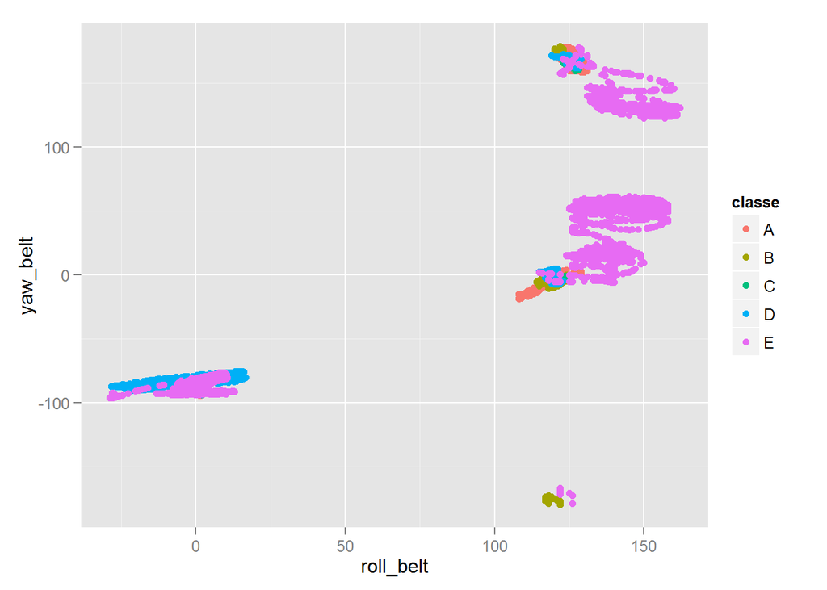

2.Plot showing roll_forearm and yaw_forearm

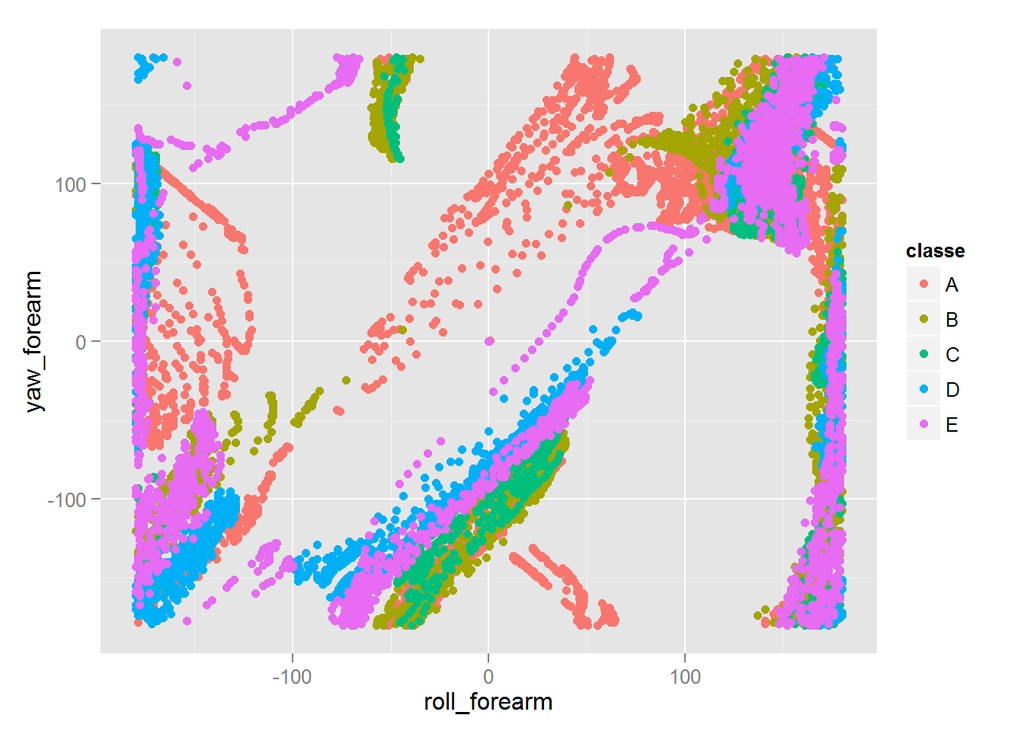

3.Plot showing ordered importance of fit1 variables.

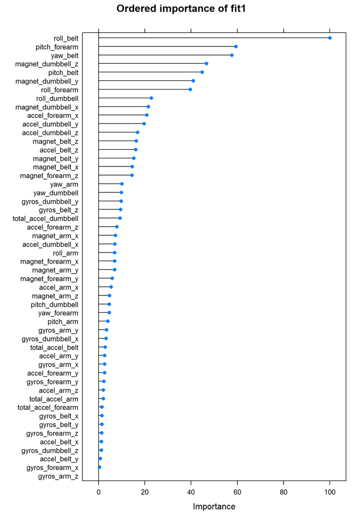